# Nonlinear Prob. Weighting, draft

Sungjoo Yoon — Camerer Group @ Caltech

2024-07-06

# Setup

To play with the QJE data, I recommend installing the ‘readstata13’ package hosted on CRAN. Other packages like ‘haven’ are notoriously slow. If your computer meets the requirements (64-bit Windows OS, sufficient RAM), I would also suggest manually increasing memory alloc. While ‘include=FALSE’ is on so this is not visible, I’m using the ‘dplyr’, ‘ggplot2’, ‘knitr’, ‘markdown’, ‘modelsummary’, ‘nls2’, ‘purrr’, ‘readstata13’, and ‘tidyverse’ packages.

# Notes

# Data

Running this next chunk will reflect why I recommend memory increases.

```r
# Reading in the data (takes an unholy amount of system memory)
dataFull <- read.dta13("QJE_data_reconstructed/betfair/Data/dataCombined2.dta")
```

```r
# Reformatting and filtering to our downsample
dataFull <- dataFull |>
  filter(sports_id == "Basketball") |>
  mutate(
    dtactual_off = as.POSIXct(dtactual_off, format="%Y-%m-%d %H:%M:%S"),
    first_taken = as.POSIXct(first_taken, format="%Y-%m-%d %H:%M:%S")
  )

# Seed for repro — shoutout Pasadena
set.seed(91125)
dataFull <- dataFull |>
  sample_n(100000)

# Function to process data chunks and mutate timestamps
process_chunk <- function(data_chunk) {
  data_chunk <- data_chunk |>
    mutate(
      event_duration = as.numeric(difftime(first_taken, dtactual_off, units = "secs"))
    ) |>
    group_by(event_id) |>
    mutate(
      event_total_duration = max(event_duration, na.rm = TRUE)
    ) |>
    ungroup()
  return(data_chunk)
}
chunk_size <- 10000
data_chunks <- split(dataFull, (seq(nrow(dataFull)) - 1) %/% chunk_size)
processed_chunks <- lapply(data_chunks, process_chunk)
dataFull_processed <- bind_rows(processed_chunks)
```

Note: pre-game odds are not available in this dataset, exclusively in-play. So instead, I took the earliest in-play bet available. Please let me know if you want me to change the approach. Otherwise, the following code also allows us to segment the last fifteen minutes of the event.

```r
# Calculating the earliest in-play bet available, which also serves as first implied odds
earliest_bets <- dataFull_processed |>
  group_by(event_id) |>
  filter(first_taken == min(first_taken)) |>
  select(event_id, first_implied = perc) |>
  ungroup()

# Merge this information back into the main dataframe
dataFull_processed <- dataFull_processed |>
  left_join(earliest_bets, by = "event_id")
# Define the late segment intervals and create time_interval variable
dataFull_processed <- dataFull_processed |>
  filter(event_duration >= (event_total_duration - 15*60)) |>
  mutate(
    time_interval = case_when(
      event_duration >= (event_total_duration - 15*60) & event_duration < (event_total_duration - 12*60) ~ "last_15_to_12",
      event_duration >= (event_total_duration - 12*60) & event_duration < (event_total_duration - 9*60) ~ "last_12_to_9",
      event_duration >= (event_total_duration - 9*60) & event_duration < (event_total_duration - 6*60) ~ "last_9_to_6",
      event_duration >= (event_total_duration - 6*60) & event_duration < (event_total_duration - 3*60) ~ "last_6_to_3",
      event_duration >= (event_total_duration - 3*60) ~ "last_3_to_0"
    )
  )
```

# Analysis

Prelec function and fitting

Draft 1 Not sure if this is right

```r
# Function for calibration curve
calculate_calibration_curve <- function(data, bins = 10) {
  data <- data |>
    mutate(bin = cut(implied_prob, breaks = bins, labels = FALSE)) |>
    group_by(bin) |>
    summarize(
      mean_pred_prob = mean(implied_prob),
      mean_actual_prob = mean(actual_prob)
    )
  return(data)
}

# Prelec 1 parameter function
prelec_w_one_param <- function(q, gamma) {
  exp(-(-log(q))^gamma)
}

# Prelec 2 parameter function
prelec_w_two_param <- function(q, gamma, delta) {
  exp(-delta * (-log(q))^gamma)
}

# Fitting Prelec 1 parameter function to calibration curve
fit_prelec_one_param_calibration <- function(data) {
  nls(mean_actual_prob ~ prelec_w_one_param(mean_pred_prob, gamma), data = data,
      start = list(gamma = 1), algorithm = "port")
}

# Fitting Prelec 2 parameter function to calibration curve
fit_prelec_two_param_calibration <- function(data) {
  nls(mean_actual_prob ~ prelec_w_two_param(mean_pred_prob, gamma, delta), data = data,
      start = list(gamma = 1, delta = 1), algorithm = "port")
}

# Function to calculate calibration curves
calculate_calibration_curve <- function(data, bins = 10) {
  data <- data |>
    mutate(bin = cut(implied_prob, breaks = bins, labels = FALSE)) |>
    group_by(bin) |>
    summarize(
      mean_pred_prob = mean(implied_prob),
      mean_actual_prob = mean(actual_prob)
    )
  return(data)
}

# Intervals as defined earlier in a structure
intervals <- c("first_implied", "last_15_to_12", "last_12_to_9", "last_9_to_6", "last_6_to_3", "last_3_to_0")

# Prepare data for fitting with calibration curves
fit_results_one_param_calibration <- list()
fit_results_two_param_calibration <- list()

# Fit Prelec function for each interval (including first implied) w/ cal.
for (interval in intervals) {
  if (interval == "first_implied") {
    subset_data <- dataFull_processed |>
      group_by(event_id) |>
      filter(first_taken == min(first_taken)) |>
      mutate(implied_prob = perc, actual_prob = win_flag)
  } else {
    subset_data <- dataFull_processed |>
      filter(time_interval == interval) |>
      mutate(implied_prob = perc, actual_prob = win_flag)
  }

  # Calculate calibration curve
  calibration_data <- calculate_calibration_curve(subset_data)

  # Fit Prelec one-parameter model to calibration curve
  prelec_fit_one_param_calibration <- fit_prelec_one_param_calibration(calibration_data)
  gamma_one_param_calibration <- coef(prelec_fit_one_param_calibration)["gamma"]
  fit_results_one_param_calibration[[interval]] <- list(interval = interval, gamma = gamma_one_param_calibration, fit = prelec_fit_one_param_calibration, data = calibration_data)

  # Fit Prelec two-parameter model to calibration curve
  prelec_fit_two_param_calibration <- fit_prelec_two_param_calibration(calibration_data)
  gamma_two_param_calibration <- coef(prelec_fit_two_param_calibration)["gamma"]
  delta_two_param_calibration <- coef(prelec_fit_two_param_calibration)["delta"]
  fit_results_two_param_calibration[[interval]] <- list(interval = interval, gamma = gamma_two_param_calibration, delta = delta_two_param_calibration, fit = prelec_fit_two_param_calibration, data = calibration_data)
}

# Fitted parameters to new df structure for 1p model using calibration curves
fit_parameters_one_param_calibration <- map_dfr(fit_results_one_param_calibration, function(res) {
  data.frame(
    interval = res$interval,
    gamma = res$gamma,
    observations = nrow(res$data),
    clusters = n_distinct(res$data$event_id),
    p_value = summary(res$fit)$coefficients["gamma", "Pr(>|t|)"]
  )
})
# Fitted parameters to new df structure for 2p model using calibration curves
fit_parameters_two_param_calibration <- map_dfr(fit_results_two_param_calibration, function(res) {
  data.frame(
    interval = res$interval,
    gamma = res$gamma,
    delta = res$delta,
    observations = nrow(res$data),
    clusters = n_distinct(res$data$event_id),
    p_value = summary(res$fit)$coefficients["gamma", "Pr(>|t|)"]
  )
})
# Tables
fit_parameters_one_param_calibration |>
  kable(col.names = c("Interval", "Gamma (Curvature)", "Observations", "Clusters", "p-value (H0: Gamma = 1)"))
```

|  | Interval | Gamma (Curvature) | Observations | Clusters | p-value (H0: Gamma = 1) |
| --- | --- | --- | --- | --- | --- |
| gamma...1 | first_implied | 1.5876639 | 7 | 0 | 0.0084363 |
| gamma...2 | last_15_to_12 | 0.9601368 | 10 | 0 | 0.0000564 |
| gamma...3 | last_12_to_9 | 0.8087471 | 10 | 0 | 0.0001752 |
| gamma...4 | last_9_to_6 | 1.1587038 | 10 | 0 | 0.0000041 |
| gamma...5 | last_6_to_3 | 1.2266805 | 10 | 0 | 0.0000002 |
| gamma...6 | last_3_to_0 | 1.0558439 | 10 | 0 | 0.0000000 |

```r
fit_parameters_two_param_calibration |>
  kable(col.names = c("Interval", "Gamma (Curvature)", "Delta (Elevation)", "Observations", "Clusters", "p-value (H0: Gamma = 1)"))
```

|  | Interval | Gamma (Curvature) | Delta (Elevation) | Observations | Clusters | p-value (H0: Gamma = 1) |
| --- | --- | --- | --- | --- | --- | --- |
| gamma...1 | first_implied | 1.5862352 | 0.9988483 | 7 | 0 | 0.2179916 |
| gamma...2 | last_15_to_12 | 0.9142696 | 0.8743932 | 10 | 0 | 0.0000871 |
| gamma...3 | last_12_to_9 | 0.7076741 | 0.7772526 | 10 | 0 | 0.0000133 |
| gamma...4 | last_9_to_6 | 1.1023219 | 0.9026284 | 10 | 0 | 0.0000073 |
| gamma...5 | last_6_to_3 | 1.1805037 | 0.9196380 | 10 | 0 | 0.0000003 |
| gamma...6 | last_3_to_0 | 1.1026350 | 1.0938470 | 10 | 0 | 0.0000000 |

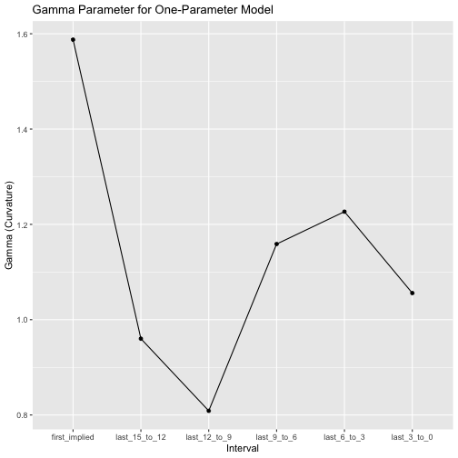

```r
# Visualization for gamma parameter in two-parameter model
fit_parameters_one_param_calibration$interval <- factor(fit_parameters_one_param_calibration$interval, levels = intervals)
fit_parameters_two_param_calibration$interval <- factor(fit_parameters_two_param_calibration$interval, levels = intervals)

ggplot(fit_parameters_one_param_calibration, aes(x = interval, y = gamma)) +
  geom_line(group = 1) +
  geom_point() +
  labs(title = "Gamma Parameter for One-Parameter Model",
       x = "Interval",
       y = "Gamma (Curvature)")
```

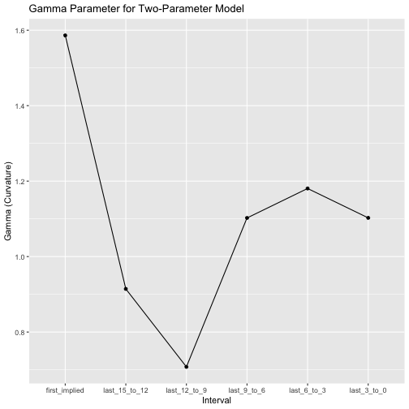

```r
ggplot(fit_parameters_two_param_calibration, aes(x = interval, y = gamma)) +
  geom_line(group = 1) +
  geom_point() +
  labs(title = "Gamma Parameter for Two-Parameter Model",
       x = "Interval",
       y = "Gamma (Curvature)")
```

Draft 0.5: just using regression to fit the data

```r
# Prelec 1 parameter function
prelec_w_one_param <- function(q, gamma) {
  exp(-(-log(q))^gamma)
}

# Fitting Prelec 1 parameter function
fit_prelec_one_param <- function(data) {
  nls(actual_prob ~ prelec_w_one_param(implied_prob, gamma), data = data,
      start = list(gamma = 1), algorithm = "port")
}

# Prelec 2
prelec_w_two_param <- function(q, gamma, delta) {
  exp(-delta * (-log(q))^gamma)
}

# Fitting Prelec 2 parameter function
fit_prelec_two_param <- function(data) {
  nls(actual_prob ~ prelec_w_two_param(implied_prob, gamma, delta), data = data,
      start = list(gamma = 1, delta = 1), algorithm = "port")
}

# Intervals as defined earlier in a structure
intervals <- c("first_implied", "last_15_to_12", "last_12_to_9", "last_9_to_6", "last_6_to_3", "last_3_to_0")

# Prepare data for fitting
fit_results_one_param <- list()
fit_results_two_param <- list()

# Fit Prelec function for each interval (including first implied)
for (interval in intervals) {
  if (interval == "first_implied") {
    subset_data <- dataFull_processed |>
      group_by(event_id) |>
      filter(first_taken == min(first_taken)) |>
      mutate(implied_prob = perc, actual_prob = win_flag)
  } else {
    subset_data <- dataFull_processed |>
      filter(time_interval == interval) |>
      mutate(implied_prob = perc, actual_prob = win_flag)
  }

  # Fit Prelec one-parameter model
  prelec_fit_one_param <- fit_prelec_one_param(subset_data)
  gamma_one_param <- coef(prelec_fit_one_param)["gamma"]
  fit_results_one_param[[interval]] <- list(interval = interval, gamma = gamma_one_param, fit = prelec_fit_one_param, data = subset_data)

  # Fit Prelec two-parameter model
  prelec_fit_two_param <- fit_prelec_two_param(subset_data)
  gamma_two_param <- coef(prelec_fit_two_param)["gamma"]
  delta_two_param <- coef(prelec_fit_two_param)["delta"]
  fit_results_two_param[[interval]] <- list(interval = interval, gamma = gamma_two_param, delta = delta_two_param, fit = prelec_fit_two_param, data = subset_data)
}

# Fitted parameters to new df structure for one-parameter model
fit_parameters_one_param <- map_dfr(fit_results_one_param, function(res) {
  data.frame(
    interval = res$interval,
    gamma = res$gamma,
    observations = nrow(res$data),
    clusters = n_distinct(res$data$event_id),
    p_value = summary(res$fit)$coefficients["gamma", "Pr(>|t|)"]
  )
})

# Fitted parameters to new df structure for two-parameter model
fit_parameters_two_param <- map_dfr(fit_results_two_param, function(res) {
  data.frame(
    interval = res$interval,
    gamma = res$gamma,
    delta = res$delta,
    observations = nrow(res$data),
    clusters = n_distinct(res$data$event_id),
    p_value = summary(res$fit)$coefficients["gamma", "Pr(>|t|)"]
  )
})

# Tables
fit_parameters_one_param |>
  kable(col.names = c("Interval", "Gamma (Curvature)", "Observations", "Clusters", "p-value (H0: Gamma = 1)"))
```

|  | Interval | Gamma (Curvature) | Observations | Clusters | p-value (H0: Gamma = 1) |
| --- | --- | --- | --- | --- | --- |
| gamma...1 | first_implied | 0.9883489 | 34991 | 33612 | 0 |
| gamma...2 | last_15_to_12 | 0.9707036 | 683 | 649 | 0 |
| gamma...3 | last_12_to_9 | 0.9544373 | 774 | 732 | 0 |
| gamma...4 | last_9_to_6 | 1.2542790 | 871 | 823 | 0 |
| gamma...5 | last_6_to_3 | 1.2874838 | 1050 | 980 | 0 |
| gamma...6 | last_3_to_0 | 1.0487914 | 86092 | 33612 | 0 |

```r
fit_parameters_two_param |>
  kable(col.names = c("Interval", "Gamma (Curvature)", "Delta (Elevation)", "Observations", "Clusters", "p-value (H0: Gamma = 1)"))
```

|  | Interval | Gamma (Curvature) | Delta (Elevation) | Observations | Clusters | p-value (H0: Gamma = 1) |
| --- | --- | --- | --- | --- | --- | --- |
| gamma...1 | first_implied | 1.0229094 | 1.0697222 | 34991 | 33612 | 0 |
| gamma...2 | last_15_to_12 | 0.8680689 | 0.8616903 | 683 | 649 | 0 |
| gamma...3 | last_12_to_9 | 0.7743088 | 0.8037398 | 774 | 732 | 0 |
| gamma...4 | last_9_to_6 | 1.1681824 | 0.9164937 | 871 | 823 | 0 |
| gamma...5 | last_6_to_3 | 1.2196140 | 0.9331590 | 1050 | 980 | 0 |
| gamma...6 | last_3_to_0 | 1.1021232 | 1.0962072 | 86092 | 33612 | 0 |

Viz 0.5

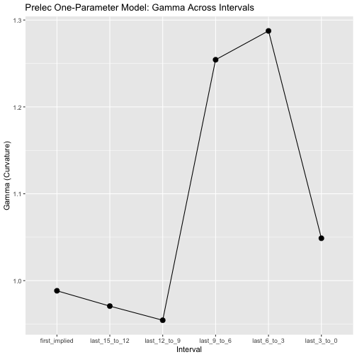

```r
fit_parameters_one_param$interval <- factor(fit_parameters_one_param$interval, levels = intervals)
fit_parameters_two_param$interval <- factor(fit_parameters_two_param$interval, levels = intervals)

plot_one_param <- ggplot(fit_parameters_one_param, aes(x = interval, y = gamma)) +
  geom_point(size = 3) +
  geom_line(group = 1) +
  labs(title = "Prelec One-Parameter Model: Gamma Across Intervals",
       x = "Interval",
       y = "Gamma (Curvature)")

# Plot for two-parameter model
plot_two_param <- ggplot(fit_parameters_two_param, aes(x = interval, y = gamma)) +
  geom_point(size = 3) +
  geom_line(group = 1) +
  labs(title = "Prelec Two-Parameter Model: Gamma Across Intervals",
       x = "Interval",
       y = "Gamma (Curvature)")

plot_one_param
```

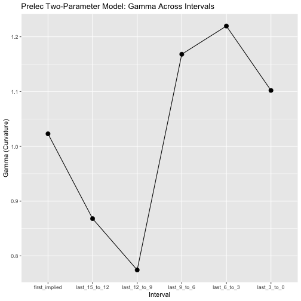

```r
plot_two_param
```

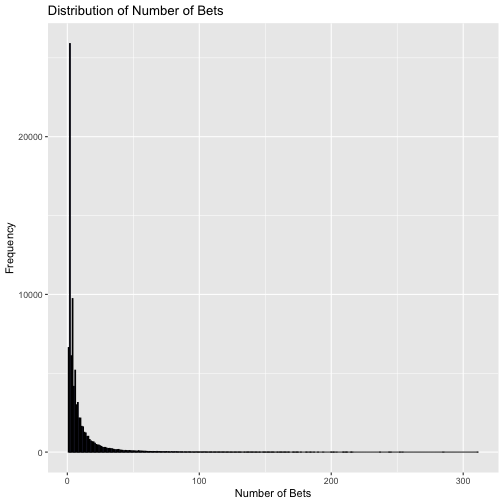

```r
# Viz on number of bets / sizes of trade
ggplot(dataFull_processed, aes(x = number_bets)) +
  geom_histogram(binwidth = 0.5, fill = "blue", color = "black", alpha = 0.7) +
  labs(title = "Distribution of Number of Bets",
       x = "Number of Bets",
       y = "Frequency")
```

Easy way to see the data at every step without bricking your computer, just run this chunk

```r
first_10000_rows <- head(dataFull_processed, 10000)
view(first_10000_rows)
```

GitHub Pages index.html generator script

```r
knit("index.Rmd", output = "index.md")
```

```
##
##
## processing file: index.Rmd
```

[output not shown]

```r
markdownToHTML("index.md", "index.html")
```